# Risk Factor Analysis

## Outcome Variable

**Outcome Variable:** whz

## Predictor Variables

**Intervention Variable:** nhh

**Adjustment Set:**

unadjusted

## Stratifying Variables

The analysis was stratified on these variable(s):

- agecat
- studyid
- country

## Data Summary

| agecat | studyid | country | nhh | n_cell | n |
| --- | --- | --- | --- | --- | --- |
| Birth | IRC | INDIA | 3 or less | 52 | 343 |
| Birth | IRC | INDIA | 4-5 | 131 | 343 |
| Birth | IRC | INDIA | 6-7 | 84 | 343 |
| Birth | IRC | INDIA | 8+ | 76 | 343 |
| Birth | NIH-Birth | BANGLADESH | 3 or less | 104 | 575 |
| Birth | NIH-Birth | BANGLADESH | 4-5 | 244 | 575 |
| Birth | NIH-Birth | BANGLADESH | 6-7 | 130 | 575 |
| Birth | NIH-Birth | BANGLADESH | 8+ | 97 | 575 |
| Birth | NIH-Crypto | BANGLADESH | 3 or less | 103 | 707 |
| Birth | NIH-Crypto | BANGLADESH | 4-5 | 318 | 707 |
| Birth | NIH-Crypto | BANGLADESH | 6-7 | 167 | 707 |
| Birth | NIH-Crypto | BANGLADESH | 8+ | 119 | 707 |
| Birth | PROVIDE | BANGLADESH | 3 or less | 103 | 532 |
| Birth | PROVIDE | BANGLADESH | 4-5 | 249 | 532 |
| Birth | PROVIDE | BANGLADESH | 6-7 | 114 | 532 |
| Birth | PROVIDE | BANGLADESH | 8+ | 66 | 532 |
| 6 months | IRC | INDIA | 3 or less | 57 | 408 |
| 6 months | IRC | INDIA | 4-5 | 157 | 408 |
| 6 months | IRC | INDIA | 6-7 | 107 | 408 |
| 6 months | IRC | INDIA | 8+ | 87 | 408 |
| 6 months | LCNI-5 | MALAWI | 3 or less | 224 | 816 |
| 6 months | LCNI-5 | MALAWI | 4-5 | 340 | 816 |
| 6 months | LCNI-5 | MALAWI | 6-7 | 182 | 816 |
| 6 months | LCNI-5 | MALAWI | 8+ | 70 | 816 |
| 6 months | NIH-Birth | BANGLADESH | 3 or less | 95 | 537 |
| 6 months | NIH-Birth | BANGLADESH | 4-5 | 227 | 537 |
| 6 months | NIH-Birth | BANGLADESH | 6-7 | 128 | 537 |
| 6 months | NIH-Birth | BANGLADESH | 8+ | 87 | 537 |
| 6 months | NIH-Crypto | BANGLADESH | 3 or less | 104 | 715 |
| 6 months | NIH-Crypto | BANGLADESH | 4-5 | 326 | 715 |
| 6 months | NIH-Crypto | BANGLADESH | 6-7 | 170 | 715 |
| 6 months | NIH-Crypto | BANGLADESH | 8+ | 115 | 715 |
| 6 months | PROVIDE | BANGLADESH | 3 or less | 105 | 603 |
| 6 months | PROVIDE | BANGLADESH | 4-5 | 289 | 603 |
| 6 months | PROVIDE | BANGLADESH | 6-7 | 130 | 603 |
| 6 months | PROVIDE | BANGLADESH | 8+ | 79 | 603 |
| 6 months | SAS-FoodSuppl | INDIA | 3 or less | 33 | 380 |
| 6 months | SAS-FoodSuppl | INDIA | 4-5 | 166 | 380 |
| 6 months | SAS-FoodSuppl | INDIA | 6-7 | 115 | 380 |
| 6 months | SAS-FoodSuppl | INDIA | 8+ | 66 | 380 |
| 24 months | IRC | INDIA | 3 or less | 58 | 409 |
| 24 months | IRC | INDIA | 4-5 | 158 | 409 |
| 24 months | IRC | INDIA | 6-7 | 107 | 409 |
| 24 months | IRC | INDIA | 8+ | 86 | 409 |
| 24 months | LCNI-5 | MALAWI | 3 or less | 157 | 558 |
| 24 months | LCNI-5 | MALAWI | 4-5 | 230 | 558 |
| 24 months | LCNI-5 | MALAWI | 6-7 | 123 | 558 |
| 24 months | LCNI-5 | MALAWI | 8+ | 48 | 558 |
| 24 months | NIH-Birth | BANGLADESH | 3 or less | 74 | 428 |
| 24 months | NIH-Birth | BANGLADESH | 4-5 | 184 | 428 |
| 24 months | NIH-Birth | BANGLADESH | 6-7 | 100 | 428 |
| 24 months | NIH-Birth | BANGLADESH | 8+ | 70 | 428 |
| 24 months | NIH-Crypto | BANGLADESH | 3 or less | 69 | 514 |
| 24 months | NIH-Crypto | BANGLADESH | 4-5 | 232 | 514 |
| 24 months | NIH-Crypto | BANGLADESH | 6-7 | 130 | 514 |
| 24 months | NIH-Crypto | BANGLADESH | 8+ | 83 | 514 |
| 24 months | PROVIDE | BANGLADESH | 3 or less | 106 | 579 |
| 24 months | PROVIDE | BANGLADESH | 4-5 | 273 | 579 |
| 24 months | PROVIDE | BANGLADESH | 6-7 | 117 | 579 |
| 24 months | PROVIDE | BANGLADESH | 8+ | 83 | 579 |

The following strata were considered:

- agecat: 24 months, studyid: IRC, country: INDIA
- agecat: 24 months, studyid: LCNI-5, country: MALAWI
- agecat: 24 months, studyid: NIH-Birth, country: BANGLADESH
- agecat: 24 months, studyid: NIH-Crypto, country: BANGLADESH
- agecat: 24 months, studyid: PROVIDE, country: BANGLADESH
- agecat: 6 months, studyid: IRC, country: INDIA
- agecat: 6 months, studyid: LCNI-5, country: MALAWI
- agecat: 6 months, studyid: NIH-Birth, country: BANGLADESH
- agecat: 6 months, studyid: NIH-Crypto, country: BANGLADESH
- agecat: 6 months, studyid: PROVIDE, country: BANGLADESH
- agecat: 6 months, studyid: SAS-FoodSuppl, country: INDIA
- agecat: Birth, studyid: IRC, country: INDIA
- agecat: Birth, studyid: NIH-Birth, country: BANGLADESH
- agecat: Birth, studyid: NIH-Crypto, country: BANGLADESH
- agecat: Birth, studyid: PROVIDE, country: BANGLADESH

## Methods Detail

We’re interested in the causal parameters $E[Y_a]$ for all values of $a \in \mathcal{A}$. These parameters represent the mean outcome if, possibly contrary to fact, we intervened to set all units to have $A=a$. Under the randomization and positivity assumptions, these are identified by the statistical parameters $\psi_a=E_W[E_{Y|A,W}(Y|A=a,W)]$. In addition, we’re interested in the mean of $Y$, $E[Y]$ under no intervention (the observed mean). We will estimate these parameters by using SuperLearner to fit the relevant likelihood factors – $E_{Y|A,W}(Y|A=a,W)$ and $p(A=a|W)$, and then updating our likelihood fit using a joint TMLE.

For unadjusted analyses ($W=\{\}$), initial likelihoods were estimated using Lrnr_glm to estimate the simple $E(Y|A)$ and Lrnr_mean to estimate $p(A)$. For adjusted analyses, a small library containing Lrnr_glmnet, Lrnr_xgboost, and Lrnr_mean was used.

Having estimated these parameters, we will then use the delta method to estimate relative risks and attributable risks relative to a prespecified baseline level of $A$.

# Results Detail

## Results Plots

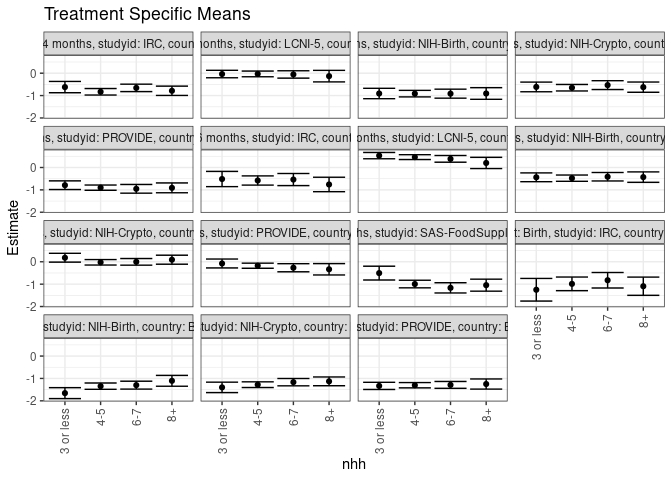

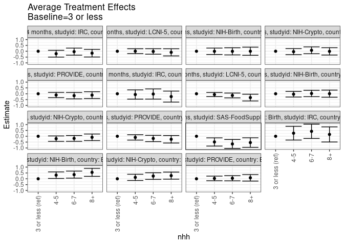

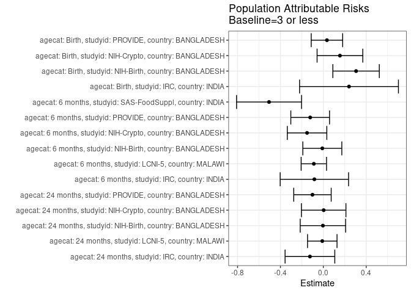

## Results Table

### Parameter: TSM

| agecat | studyid | country | intervention_level | baseline_level | estimate | ci_lower | ci_upper |
| --- | --- | --- | --- | --- | --- | --- | --- |
| Birth | IRC | INDIA | 3 or less | NA | -1.2501923 | -1.7553866 | -0.7449980 |
| Birth | IRC | INDIA | 4-5 | NA | -0.9866412 | -1.2906453 | -0.6826371 |
| Birth | IRC | INDIA | 6-7 | NA | -0.8254762 | -1.1713949 | -0.4795575 |
| Birth | IRC | INDIA | 8+ | NA | -1.0925000 | -1.4994234 | -0.6855766 |
| Birth | NIH-Birth | BANGLADESH | 3 or less | NA | -1.6555288 | -1.8996731 | -1.4113846 |
| Birth | NIH-Birth | BANGLADESH | 4-5 | NA | -1.3438934 | -1.4845369 | -1.2032500 |
| Birth | NIH-Birth | BANGLADESH | 6-7 | NA | -1.2991538 | -1.4752310 | -1.1230767 |
| Birth | NIH-Birth | BANGLADESH | 8+ | NA | -1.1054639 | -1.3467645 | -0.8641633 |
| Birth | NIH-Crypto | BANGLADESH | 3 or less | NA | -1.3991262 | -1.6318640 | -1.1663885 |
| Birth | NIH-Crypto | BANGLADESH | 4-5 | NA | -1.2783805 | -1.4055825 | -1.1511785 |
| Birth | NIH-Crypto | BANGLADESH | 6-7 | NA | -1.1652096 | -1.3289318 | -1.0014874 |
| Birth | NIH-Crypto | BANGLADESH | 8+ | NA | -1.1293277 | -1.3253779 | -0.9332775 |
| Birth | PROVIDE | BANGLADESH | 3 or less | NA | -1.3322330 | -1.4919147 | -1.1725514 |
| Birth | PROVIDE | BANGLADESH | 4-5 | NA | -1.3022892 | -1.4207335 | -1.1838448 |
| Birth | PROVIDE | BANGLADESH | 6-7 | NA | -1.2883333 | -1.4417204 | -1.1349462 |
| Birth | PROVIDE | BANGLADESH | 8+ | NA | -1.2487879 | -1.4749767 | -1.0225991 |
| 6 months | IRC | INDIA | 3 or less | NA | -0.5154386 | -0.8555810 | -0.1752962 |
| 6 months | IRC | INDIA | 4-5 | NA | -0.5811677 | -0.7868221 | -0.3755133 |
| 6 months | IRC | INDIA | 6-7 | NA | -0.5393769 | -0.8095791 | -0.2691748 |
| 6 months | IRC | INDIA | 8+ | NA | -0.7589272 | -1.0822316 | -0.4356228 |
| 6 months | LCNI-5 | MALAWI | 3 or less | NA | 0.5302679 | 0.3896788 | 0.6708569 |
| 6 months | LCNI-5 | MALAWI | 4-5 | NA | 0.4629412 | 0.3554643 | 0.5704181 |
| 6 months | LCNI-5 | MALAWI | 6-7 | NA | 0.3854396 | 0.2357481 | 0.5351310 |
| 6 months | LCNI-5 | MALAWI | 8+ | NA | 0.2021429 | -0.0488970 | 0.4531827 |
| 6 months | NIH-Birth | BANGLADESH | 3 or less | NA | -0.4380702 | -0.6344240 | -0.2417164 |
| 6 months | NIH-Birth | BANGLADESH | 4-5 | NA | -0.4771769 | -0.6170732 | -0.3372807 |
| 6 months | NIH-Birth | BANGLADESH | 6-7 | NA | -0.4131315 | -0.6027632 | -0.2234998 |
| 6 months | NIH-Birth | BANGLADESH | 8+ | NA | -0.4303352 | -0.6631293 | -0.1975412 |
| 6 months | NIH-Crypto | BANGLADESH | 3 or less | NA | 0.1815385 | -0.0163587 | 0.3794357 |
| 6 months | NIH-Crypto | BANGLADESH | 4-5 | NA | -0.0237577 | -0.1456473 | 0.0981320 |
| 6 months | NIH-Crypto | BANGLADESH | 6-7 | NA | -0.0028824 | -0.1508866 | 0.1451219 |
| 6 months | NIH-Crypto | BANGLADESH | 8+ | NA | 0.0924783 | -0.1084867 | 0.2934432 |
| 6 months | PROVIDE | BANGLADESH | 3 or less | NA | -0.0764762 | -0.2753687 | 0.1224163 |
| 6 months | PROVIDE | BANGLADESH | 4-5 | NA | -0.1761073 | -0.2898152 | -0.0623993 |
| 6 months | PROVIDE | BANGLADESH | 6-7 | NA | -0.2662051 | -0.4473589 | -0.0850514 |
| 6 months | PROVIDE | BANGLADESH | 8+ | NA | -0.3356962 | -0.5894909 | -0.0819015 |
| 6 months | SAS-FoodSuppl | INDIA | 3 or less | NA | -0.5057576 | -0.8139467 | -0.1975684 |
| 6 months | SAS-FoodSuppl | INDIA | 4-5 | NA | -0.9942169 | -1.1635351 | -0.8248986 |
| 6 months | SAS-FoodSuppl | INDIA | 6-7 | NA | -1.1646087 | -1.3932289 | -0.9359885 |
| 6 months | SAS-FoodSuppl | INDIA | 8+ | NA | -1.0448485 | -1.3121213 | -0.7775757 |
| 24 months | IRC | INDIA | 3 or less | NA | -0.6209770 | -0.8730190 | -0.3689350 |
| 24 months | IRC | INDIA | 4-5 | NA | -0.8305802 | -0.9756749 | -0.6854855 |
| 24 months | IRC | INDIA | 6-7 | NA | -0.6561682 | -0.8217662 | -0.4905702 |
| 24 months | IRC | INDIA | 8+ | NA | -0.7858140 | -0.9939620 | -0.5776660 |
| 24 months | LCNI-5 | MALAWI | 3 or less | NA | -0.0380892 | -0.2047895 | 0.1286112 |
| 24 months | LCNI-5 | MALAWI | 4-5 | NA | -0.0328043 | -0.1602906 | 0.0946819 |
| 24 months | LCNI-5 | MALAWI | 6-7 | NA | -0.0556098 | -0.2203539 | 0.1091343 |
| 24 months | LCNI-5 | MALAWI | 8+ | NA | -0.1312500 | -0.3891478 | 0.1266478 |
| 24 months | NIH-Birth | BANGLADESH | 3 or less | NA | -0.9077477 | -1.1399785 | -0.6755170 |
| 24 months | NIH-Birth | BANGLADESH | 4-5 | NA | -0.9133243 | -1.0599469 | -0.7667017 |
| 24 months | NIH-Birth | BANGLADESH | 6-7 | NA | -0.9146917 | -1.1151591 | -0.7142242 |
| 24 months | NIH-Birth | BANGLADESH | 8+ | NA | -0.9065952 | -1.1666898 | -0.6465007 |
| 24 months | NIH-Crypto | BANGLADESH | 3 or less | NA | -0.6136232 | -0.8297405 | -0.3975059 |
| 24 months | NIH-Crypto | BANGLADESH | 4-5 | NA | -0.6484483 | -0.7929739 | -0.5039227 |
| 24 months | NIH-Crypto | BANGLADESH | 6-7 | NA | -0.5323077 | -0.7295402 | -0.3350752 |
| 24 months | NIH-Crypto | BANGLADESH | 8+ | NA | -0.6233735 | -0.8517043 | -0.3950427 |
| 24 months | PROVIDE | BANGLADESH | 3 or less | NA | -0.7916038 | -0.9849765 | -0.5982311 |
| 24 months | PROVIDE | BANGLADESH | 4-5 | NA | -0.9012088 | -1.0180380 | -0.7843796 |
| 24 months | PROVIDE | BANGLADESH | 6-7 | NA | -0.9530769 | -1.1470440 | -0.7591099 |
| 24 months | PROVIDE | BANGLADESH | 8+ | NA | -0.9098795 | -1.1292559 | -0.6905031 |

### Parameter: E(Y)

| agecat | studyid | country | intervention_level | baseline_level | estimate | ci_lower | ci_upper |
| --- | --- | --- | --- | --- | --- | --- | --- |
| Birth | IRC | INDIA | NA | NA | -1.0105831 | -1.1973019 | -0.8238643 |
| Birth | NIH-Birth | BANGLADESH | NA | NA | -1.3499217 | -1.4444634 | -1.2553801 |
| Birth | NIH-Crypto | BANGLADESH | NA | NA | -1.2441513 | -1.3281130 | -1.1601897 |
| Birth | PROVIDE | BANGLADESH | NA | NA | -1.2984586 | -1.3752758 | -1.2216415 |
| 6 months | IRC | INDIA | NA | NA | -0.5989297 | -0.7344491 | -0.4634104 |
| 6 months | LCNI-5 | MALAWI | NA | NA | 0.4417647 | 0.3702742 | 0.5132552 |
| 6 months | NIH-Birth | BANGLADESH | NA | NA | -0.4474038 | -0.5378167 | -0.3569909 |
| 6 months | NIH-Crypto | BANGLADESH | NA | NA | 0.0297622 | -0.0491685 | 0.1086930 |
| 6 months | PROVIDE | BANGLADESH | NA | NA | -0.1990907 | -0.2817968 | -0.1163845 |
| 6 months | SAS-FoodSuppl | INDIA | NA | NA | -1.0121579 | -1.1280429 | -0.8962729 |
| 24 months | IRC | INDIA | NA | NA | -0.7458150 | -0.8368180 | -0.6548120 |
| 24 months | LCNI-5 | MALAWI | NA | NA | -0.0477867 | -0.1301103 | 0.0345368 |
| 24 months | NIH-Birth | BANGLADESH | NA | NA | -0.9115790 | -1.0095022 | -0.8136559 |
| 24 months | NIH-Crypto | BANGLADESH | NA | NA | -0.6103502 | -0.7050157 | -0.5156847 |
| 24 months | PROVIDE | BANGLADESH | NA | NA | -0.8928670 | -0.9755153 | -0.8102187 |

### Parameter: ATE

| agecat | studyid | country | intervention_level | baseline_level | estimate | ci_lower | ci_upper |
| --- | --- | --- | --- | --- | --- | --- | --- |
| Birth | IRC | INDIA | 3 or less | 3 or less | 0.0000000 | 0.0000000 | 0.0000000 |
| Birth | IRC | INDIA | 4-5 | 3 or less | 0.2635511 | -0.3260588 | 0.8531609 |
| Birth | IRC | INDIA | 6-7 | 3 or less | 0.4247161 | -0.1875592 | 1.0369914 |
| Birth | IRC | INDIA | 8+ | 3 or less | 0.1576923 | -0.4910048 | 0.8063894 |
| Birth | NIH-Birth | BANGLADESH | 3 or less | 3 or less | 0.0000000 | 0.0000000 | 0.0000000 |
| Birth | NIH-Birth | BANGLADESH | 4-5 | 3 or less | 0.3116354 | 0.0298785 | 0.5933924 |
| Birth | NIH-Birth | BANGLADESH | 6-7 | 3 or less | 0.3563750 | 0.0553608 | 0.6573892 |
| Birth | NIH-Birth | BANGLADESH | 8+ | 3 or less | 0.5500649 | 0.2067977 | 0.8933321 |
| Birth | NIH-Crypto | BANGLADESH | 3 or less | 3 or less | 0.0000000 | 0.0000000 | 0.0000000 |
| Birth | NIH-Crypto | BANGLADESH | 4-5 | 3 or less | 0.1207457 | -0.1444848 | 0.3859762 |
| Birth | NIH-Crypto | BANGLADESH | 6-7 | 3 or less | 0.2339166 | -0.0506388 | 0.5184721 |
| Birth | NIH-Crypto | BANGLADESH | 8+ | 3 or less | 0.2697985 | -0.0345082 | 0.5741051 |
| Birth | PROVIDE | BANGLADESH | 3 or less | 3 or less | 0.0000000 | 0.0000000 | 0.0000000 |
| Birth | PROVIDE | BANGLADESH | 4-5 | 3 or less | 0.0299439 | -0.1688709 | 0.2287586 |
| Birth | PROVIDE | BANGLADESH | 6-7 | 3 or less | 0.0438997 | -0.1775181 | 0.2653175 |
| Birth | PROVIDE | BANGLADESH | 8+ | 3 or less | 0.0834451 | -0.1934296 | 0.3603199 |
| 6 months | IRC | INDIA | 3 or less | 3 or less | 0.0000000 | 0.0000000 | 0.0000000 |
| 6 months | IRC | INDIA | 4-5 | 3 or less | -0.0657291 | -0.4632094 | 0.3317512 |
| 6 months | IRC | INDIA | 6-7 | 3 or less | -0.0239384 | -0.4583414 | 0.4104647 |
| 6 months | IRC | INDIA | 8+ | 3 or less | -0.2434886 | -0.7127674 | 0.2257901 |
| 6 months | LCNI-5 | MALAWI | 3 or less | 3 or less | 0.0000000 | 0.0000000 | 0.0000000 |
| 6 months | LCNI-5 | MALAWI | 4-5 | 3 or less | -0.0673267 | -0.2442915 | 0.1096382 |
| 6 months | LCNI-5 | MALAWI | 6-7 | 3 or less | -0.1448283 | -0.3501885 | 0.0605319 |
| 6 months | LCNI-5 | MALAWI | 8+ | 3 or less | -0.3281250 | -0.6158511 | -0.0403989 |
| 6 months | NIH-Birth | BANGLADESH | 3 or less | 3 or less | 0.0000000 | 0.0000000 | 0.0000000 |
| 6 months | NIH-Birth | BANGLADESH | 4-5 | 3 or less | -0.0391068 | -0.2801997 | 0.2019861 |
| 6 months | NIH-Birth | BANGLADESH | 6-7 | 3 or less | 0.0249387 | -0.2480357 | 0.2979130 |
| 6 months | NIH-Birth | BANGLADESH | 8+ | 3 or less | 0.0077349 | -0.2968105 | 0.3122803 |
| 6 months | NIH-Crypto | BANGLADESH | 3 or less | 3 or less | 0.0000000 | 0.0000000 | 0.0000000 |
| 6 months | NIH-Crypto | BANGLADESH | 4-5 | 3 or less | -0.2052961 | -0.4377190 | 0.0271267 |
| 6 months | NIH-Crypto | BANGLADESH | 6-7 | 3 or less | -0.1844208 | -0.4315414 | 0.0626997 |
| 6 months | NIH-Crypto | BANGLADESH | 8+ | 3 or less | -0.0890602 | -0.3711067 | 0.1929863 |
| 6 months | PROVIDE | BANGLADESH | 3 or less | 3 or less | 0.0000000 | 0.0000000 | 0.0000000 |
| 6 months | PROVIDE | BANGLADESH | 4-5 | 3 or less | -0.0996311 | -0.3287331 | 0.1294709 |
| 6 months | PROVIDE | BANGLADESH | 6-7 | 3 or less | -0.1897289 | -0.4587548 | 0.0792969 |
| 6 months | PROVIDE | BANGLADESH | 8+ | 3 or less | -0.2592200 | -0.5816638 | 0.0632237 |
| 6 months | SAS-FoodSuppl | INDIA | 3 or less | 3 or less | 0.0000000 | 0.0000000 | 0.0000000 |
| 6 months | SAS-FoodSuppl | INDIA | 4-5 | 3 or less | -0.4884593 | -0.8400972 | -0.1368214 |
| 6 months | SAS-FoodSuppl | INDIA | 6-7 | 3 or less | -0.6588511 | -1.0425799 | -0.2751224 |
| 6 months | SAS-FoodSuppl | INDIA | 8+ | 3 or less | -0.5390909 | -0.9470312 | -0.1311506 |
| 24 months | IRC | INDIA | 3 or less | 3 or less | 0.0000000 | 0.0000000 | 0.0000000 |
| 24 months | IRC | INDIA | 4-5 | 3 or less | -0.2096032 | -0.5004255 | 0.0812192 |
| 24 months | IRC | INDIA | 6-7 | 3 or less | -0.0351912 | -0.3367669 | 0.2663844 |
| 24 months | IRC | INDIA | 8+ | 3 or less | -0.1648369 | -0.4917173 | 0.1620434 |
| 24 months | LCNI-5 | MALAWI | 3 or less | 3 or less | 0.0000000 | 0.0000000 | 0.0000000 |
| 24 months | LCNI-5 | MALAWI | 4-5 | 3 or less | 0.0052848 | -0.2045764 | 0.2151461 |
| 24 months | LCNI-5 | MALAWI | 6-7 | 3 or less | -0.0175206 | -0.2518913 | 0.2168501 |
| 24 months | LCNI-5 | MALAWI | 8+ | 3 or less | -0.0931608 | -0.4002444 | 0.2139227 |
| 24 months | NIH-Birth | BANGLADESH | 3 or less | 3 or less | 0.0000000 | 0.0000000 | 0.0000000 |
| 24 months | NIH-Birth | BANGLADESH | 4-5 | 3 or less | -0.0055765 | -0.2802205 | 0.2690675 |
| 24 months | NIH-Birth | BANGLADESH | 6-7 | 3 or less | -0.0069439 | -0.3137310 | 0.2998432 |
| 24 months | NIH-Birth | BANGLADESH | 8+ | 3 or less | 0.0011525 | -0.3475312 | 0.3498362 |
| 24 months | NIH-Crypto | BANGLADESH | 3 or less | 3 or less | 0.0000000 | 0.0000000 | 0.0000000 |
| 24 months | NIH-Crypto | BANGLADESH | 4-5 | 3 or less | -0.0348251 | -0.2948142 | 0.2251640 |
| 24 months | NIH-Crypto | BANGLADESH | 6-7 | 3 or less | 0.0813155 | -0.2112719 | 0.3739029 |
| 24 months | NIH-Crypto | BANGLADESH | 8+ | 3 or less | -0.0097503 | -0.3241412 | 0.3046406 |
| 24 months | PROVIDE | BANGLADESH | 3 or less | 3 or less | 0.0000000 | 0.0000000 | 0.0000000 |
| 24 months | PROVIDE | BANGLADESH | 4-5 | 3 or less | -0.1096050 | -0.3355299 | 0.1163199 |
| 24 months | PROVIDE | BANGLADESH | 6-7 | 3 or less | -0.1614731 | -0.4353640 | 0.1124177 |
| 24 months | PROVIDE | BANGLADESH | 8+ | 3 or less | -0.1182757 | -0.4107121 | 0.1741606 |

### Parameter: PAR

| agecat | studyid | country | intervention_level | baseline_level | estimate | ci_lower | ci_upper |
| --- | --- | --- | --- | --- | --- | --- | --- |
| Birth | IRC | INDIA | 3 or less | NA | 0.2396092 | -0.2215852 | 0.7008037 |
| Birth | NIH-Birth | BANGLADESH | 3 or less | NA | 0.3056071 | 0.0888525 | 0.5223617 |
| Birth | NIH-Crypto | BANGLADESH | 3 or less | NA | 0.1549749 | -0.0581770 | 0.3681267 |
| Birth | PROVIDE | BANGLADESH | 3 or less | NA | 0.0337744 | -0.1129421 | 0.1804908 |
| 6 months | IRC | INDIA | 3 or less | NA | -0.0834911 | -0.4024508 | 0.2354685 |
| 6 months | LCNI-5 | MALAWI | 3 or less | NA | -0.0885032 | -0.2069288 | 0.0299225 |
| 6 months | NIH-Birth | BANGLADESH | 3 or less | NA | -0.0093336 | -0.1912345 | 0.1725673 |
| 6 months | NIH-Crypto | BANGLADESH | 3 or less | NA | -0.1517762 | -0.3361682 | 0.0326158 |
| 6 months | PROVIDE | BANGLADESH | 3 or less | NA | -0.1226145 | -0.3032302 | 0.0580013 |
| 6 months | SAS-FoodSuppl | INDIA | 3 or less | NA | -0.5064003 | -0.8095723 | -0.2032283 |
| 24 months | IRC | INDIA | 3 or less | NA | -0.1248380 | -0.3567643 | 0.1070883 |
| 24 months | LCNI-5 | MALAWI | 3 or less | NA | -0.0096976 | -0.1472789 | 0.1278838 |
| 24 months | NIH-Birth | BANGLADESH | 3 or less | NA | -0.0038313 | -0.2156590 | 0.2079964 |
| 24 months | NIH-Crypto | BANGLADESH | 3 or less | NA | 0.0032730 | -0.2044006 | 0.2109466 |
| 24 months | PROVIDE | BANGLADESH | 3 or less | NA | -0.1012632 | -0.2759983 | 0.0734718 |